# FE8828 Programming Web Applications in Finance

# Header

```
# Header1
## Header2
### Header3
```

## Block quote

```
> markdown
> /ˈmɑːkdəʊn/
> noun
> noun: markdown; plural noun: markdowns; noun: mark-down; plural noun: mark-downs
> a reduction in price.
> "markdowns of up to 50 per cent on many items"
```

## List

- First paragraph.

Continued.

- Second paragraph. With a code block, which must be indented eight spaces:

  { code }
  - First paragraph.

    Continued.
  - Second paragraph. With a code block, which must be indented eight spaces:

    { code }

# Multi-level lists

```
* fruits
    + apples
        - macintosh
        - red delicious
    + pears
    + peaches
* vegetables
    + broccoli
    + chard
```

- fruits
  - apples
    - macintosh
    - red delicious
  - pears
- vegetables
  - broccoli
  - chard

# Ordered Lists

```
#.
#.
```

# Table

```
| Tables        | Are           | Cool  |
| ------------- |:-------------:| -----:|
| col 3 is      | right-aligned | $1600 |
| col 2 is      | centered      |   $12 |
| zebra stripes | are neat      |    $1 |
```

| Tables | Are | Cool |
| --- | --- | --- |
| col 3 is | right-aligned | $1600 |
| col 2 is | centered | $12 |
| zebra stripes | are neat | $1 |

# Inline formatting

Emphasis To emphasize some text, surround it with *s or _, like this:

This text is *emphasized with underscores*, and this is *emphasized with asterisks*. Double * or _ produces strong emphasis:

This is **strong emphasis** and **with underscores**. A * or _ character surrounded by spaces, or backslash-escaped, will not trigger emphasis:

This is * not emphasized *, and *neither is this*. Extension: intraword_underscores

Because _ is sometimes used inside words and identifiers, pandoc does not interpret a _ surrounded by alphanumeric characters as an emphasis marker. If you want to emphasize just part of a word, use *:

feas*ible*, not feas*able*. Strikeout Extension: strikeout

To strikeout a section of text with a horizontal line, begin and end it with ~~. Thus, for example,

This is deleted text. Superscripts and subscripts Extension: superscript, subscript

Superscripts may be written by surrounding the superscripted text by ^ characters; subscripts may be written by surrounding the subscripted text by ~ characters. Thus, for example,

H<sub>2</sub>O is a liquid. 2<sup>10</sup> is 1024. If the superscripted or subscripted text contains spaces, these spaces must be escaped with backslashes. (This is to prevent accidental superscripting and subscripting through the ordinary use of ~ and ^.) Thus, if you want the letter P with ‘a cat’ in subscripts, use P<sub>a cat</sub>, not P~a cat~.

Verbatim To make a short span of text verbatim, put it inside backticks:

What is the difference between `>>=` and `>>`? If the verbatim text includes a backtick, use double backticks:

Here is a literal backtick `` ` ``.

# Links

Markdown allows links to be specified in several ways.

Automatic links If you enclose a URL or email address in pointy brackets, it will become a link:

http://google.com sam@green.eggs.ham Inline links An inline link consists of the link text in square brackets, followed by the URL in parentheses. (Optionally, the URL can be followed by a link title, in quotes.)

This is an inline link, and here’s [one with a title](http://fsf.org).

# images

A link immediately preceded by a ! will be treated as an image. The link text will be used as the image’s alt text:

```
![la lune](lalune.jpg "Voyage to the moon")

![movie reel]

[movie reel]: movie.gif
```

An image occurring by itself in a paragraph will be rendered as a figure with a caption.4 (In LaTeX, a figure environment will be used; in HTML, the image will be placed in a div with class figure, together with a caption in a p with class caption.) The image’s alt text will be used as the caption.

```
![This is the caption](/url/of/image.png)
```

# Verbatim (Code) block

```
if (a > 3) {
  moveShip(5 * gravity, DOWN);
}
```

## Code block for R Markdown

R Markdown is a extension to Markdown that you can execute code among the code. (Not only R, but Python, etc.) If you name the file as .Rmd and *knit* in R Studio.

The name is optional; if included, each code chunk needs a distinct name. It’s usually best to give each code chunk a name.

The advantage of giving each chunk a name is that it will be easier to understand where to look for errors, should they occur. Also, any figures that are created will be given names based on the name of the code chunk that produced them.

# chunk options

[output not shown]

# R Shiny

Just about layout and some R Syntax

# HTML UI

# add static content

```
tags$h1()
tags$a()
tagList()
```

# Panel

```
titlePanel("Hello Shiny!")

wellPanel(actionButton("goButton", "Go!"))

tabPanel("tab 1")

tabsetPanel(
  tabPanel("Plot", plotOutput("plot")),
  tabPanel("Summary", verbatimTextOutput("summary")),
  tabPanel("Table", tableOutput("table"))
)

navlistPanel(
  tabPanel("tab1", "contents"),
  tabPanel("tab2", "contents"),
  tabPanel("tab3", "contents")
)
```

# HTML layout

```
ui <- fluidPage(
  fluidRow(column(3),
          column(5)),
  fluidRow(column(4), offset = 8)
  )
```

# Sidebar layout - Prepacked layout

```
fluidPage(sidebarLayout(
  sidebarPanel(),
  mainPanel()
))

fluidPage(
  titlePanel("Hello Shiny!"),
  sidebarLayout(
    sidebarPanel(
      sliderInput("obs", "Number of observations:",
                  min = 1, max = 1000, value = 500)
    ),
    mainPanel(
      plotOutput("distPlot")
    )
  )
)
```

# Sidebar layout with bar on the right

# Column-based layout

Caveat: There is fluidRow, but no fluidColumn.

```
fluidPage(
  fluidRow(
    column(2, "sidebar" ),
    column(10, "main" )
  )
)

fluidPage(
  titlePanel("Hello Shiny!"),
  fluidRow(
    column(4,
      wellPanel(
        dateInput("date", "How's weather today?")
      )
    ),
    column(8,
      h3("Plot")
      plotOutput("distPlot")
    )
  )
)
```

# Composition layout: Top and Down

```
fluidPage(
  title = "Diamonds Explorer",
  img(),
  hr(),

  fluidRow(
    column(3,
      h4("Diamonds Explorer"),
      sliderInput('sampleSize', 'Sample Size',
                  min=1, max=nrow(dataset), value=min(1000, nrow(dataset)),
                  step=500, round=0),
      br(),
      checkboxInput('jitter', 'Jitter'),
      checkboxInput('smooth', 'Smooth')
    ),
    column(4, offset = 1,
      selectInput('x', 'X', names(dataset)),
      selectInput('y', 'Y', names(dataset), names(dataset)[[2]]),
      selectInput('color', 'Color', c('None', names(dataset)))
    ),
    column(4,
      selectInput('facet_row', 'Facet Row', c(None='.', names(dataset))),
      selectInput('facet_col', 'Facet Column', c(None='.', names(dataset)))
    )
  )
)
```

# Navlist panel

```
fluidPage(
  titlePanel("Application Title"),

  navlistPanel(
    "Header A",
    tabPanel("Component 1"),
    tabPanel("Component 2"),
    "Header B",
    tabPanel("Component 3"),
    tabPanel("Component 4"),
    "-----",
    tabPanel("Component 5")
  )
)
```

# NavbarPanel

```
navbarPage(title = "title",
  tabPanel("tab 1", "content"),
  tabPanel("tab 2", "content"),
  navbarMenu(title = "title",
    tabPanel("tab 3", "content"),
    tabPanel("tab 3", "content")
  )
)
```

# 2nd secondary

```
navbarPage("My Application",
  tabPanel("Component 1"),
  tabPanel("Component 2"),
  navbarMenu("More",
    tabPanel("Sub-Component A"),
    tabPanel("Sub-Component B"))
)
```

## Slide with R Output

```r
summary(cars)
```

```
##      speed           dist
##  Min.   : 4.0   Min.   :  2.00
##  1st Qu.:12.0   1st Qu.: 26.00
##  Median :15.0   Median : 36.00
##  Mean   :15.4   Mean   : 42.98
##  3rd Qu.:19.0   3rd Qu.: 56.00
##  Max.   :25.0   Max.   :120.00
```

```r
a <- filter(cars, speed > 4)
a
```

| speed | dist |
| --- | --- |
| 7 | 4 |
| 7 | 22 |
| 8 | 16 |
| 9 | 10 |
| 10 | 18 |
| 10 | 26 |
| 10 | 34 |
| 11 | 17 |
| 11 | 28 |
| 12 | 14 |

[output cut: 38 more lines]

## Slide with Plot

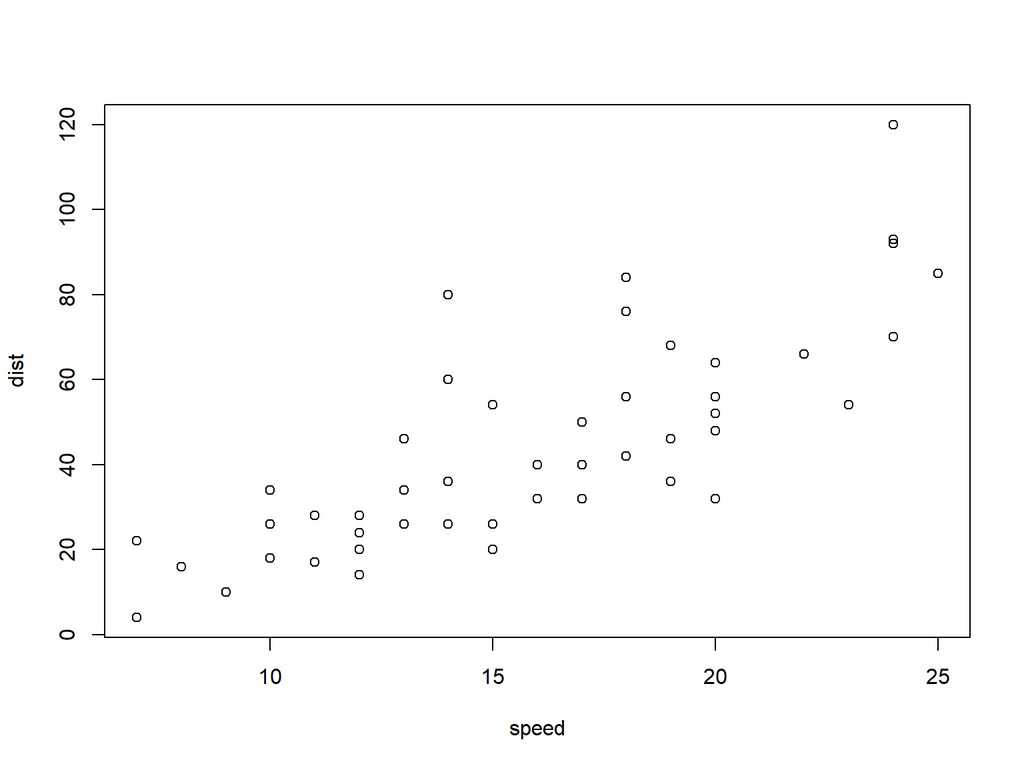